# VL12: Ableiten und Unifikation

IFM 5.14 Künstliche Intelligenz, W19

Carsten Gips, FH Bielefeld

# Wiederholung

## Formeln und Modelle

Betrachten Sie folgende Aussagen:

- Alle Menschen sind sterblich.
- Sokrates ist ein Mensch.
1. Geben Sie passende Formeln an.
2. Geben Sie ein Modell für die Formeln an.
- Formeln im PK1 angeben
  - $\forall x \, mensch(x) \Rightarrow sterblich(x)$
  - $mensch(Sokrates)$
- Signatur $\Sigma = (S, F, P, \alpha)$
- Algebra $\mathcal{A} = (\Sigma, \Delta, \Phi, \Psi)$
- Modell ($\mathcal{A} \models H$): Formeln müssen in der Algebra $\mathcal{A}$ unter **jeder** Belegung $\sigma$ gelten, d.h. für alle $\sigma$ gilt $I_{\mathcal{A},\sigma}(H) = 1$

# Motivation

## Beantworten von Fragen

- Dudley isst.
- Tante Petunia ist glücklich, wenn Dudley glücklich ist.
- Onkel Vernon ist glücklich, wenn Dudley glücklich ist und Harry unglücklich ist.
- Dudley ist glücklich, wenn er Harry ärgern kann.
- Dudley ist glücklich, wenn er isst.
- Harry ist unglücklich, wenn er von jemanden geärgert wird.
- Dudley ärgert Harry.
- Ist Tante Petunia glücklich?

=> Formalisierung und Kalkül für Inferenz nötig

## Themen für heute

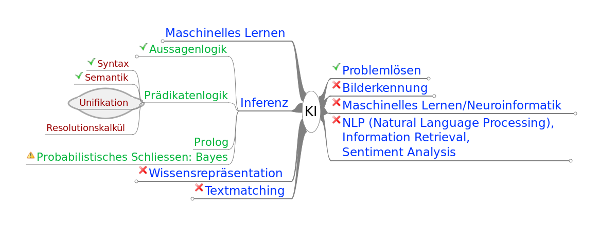

Am Ende der VL können/verstehen Sie:

- Idee hinter syntaktischem **Ableiten**
- Substitution und **Unifikation**

# Syntaktisches Ableiten als Beweisform

## Erinnerung: Modelle, Semantisches Folgern

- **Modell**: $\mathcal{A} \models H$, falls für alle $\sigma$ gilt $I_{\mathcal{A},\sigma}(H) = 1$
- **Semantisches Folgern**: Formel $Q$ folgt *semantisch* aus Formel(n) $WB$, wenn jedes Modell von $WB$ auch Modell von $Q$ ist

  $$WB \models Q$$

Hinweis auf Wahrheitstafel (Argumentation alle Modelle)

Man betrachtet die Auswirkungen der Modelle auf die Formeln: Eine Algebra ist genau dann Modell für die Formeln, wenn diese unter jeder Belegung gelten. D.h. man kann eine Wahrheitstabelle aufstellen, wo man die Gültigkeit der einzelnen Prädikate variiert (Kombinatorik).

Dieses Vorgehen ist in der Praxis i.d.R. nicht machbar, da viel zu komplex! Deshalb sucht man nach alternativen Verfahren. Hilfreich wäre es, wenn man Regeln hätte, mit denen man direkt über die Syntax ableiten und beweisen könnte, anstatt immer über die Bedeutung und Interpretation zu gehen. Darum wird es in den folgenden Folien gehen.

## Semantisches Folgern vs. Syntaktisches Ableiten

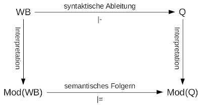

- Semantisches Folgern: Argumentation über **alle** Modelle
- Syntaktisches Ableiten: Syntaktische Regeln zum Ableiten von Formeln (=> **Kalkül**)

Beim Folgern muss man die Formeln *interpretieren* und für die Wissensbasis $WB$ und die Anfrage $Q$ *alle* Modelle betrachten, um daraus Schlüsse zu ziehen.

Beim Ableiten erfolgt dies direkt auf den Formeln, d.h. es gibt eine Reihe von Regeln, um die Formeln umzuformen und Schlüsse zu ziehen, ohne an eine mögliche Interpretation zu denken.

## Begriffe zu Kalkülen

- Kalkül ist **korrekt** (“*sound*”): Wenn $WB \vdash Q$ dann $WB \models Q$.

  Jede im Kalkül syntaktisch abgeleitete Aussage folgt auch semantisch.

  => Keine falschen Folgerungen
- Kalkül ist **vollständig** (“*complete*”): Wenn $WB \models Q$ dann $WB \vdash Q$.

  Alle semantischen Folgerungen können über Anwendung syntaktischer Regeln im Kalkül abgeleitet werden.

  => Kalkül übersieht nichts

## Syntaktisches Beweisen: Modus Ponens

$$\dfrac{A, \; A \Rightarrow B}{B}$$

*Hinweis*: $A \Rightarrow B$ entspricht $\neg A \vee B$ (Wahrheitstafel!)

Beweis: Wahrheitstafel

## Syntaktisches Beweisen: $\forall$-Elimination

$$\dfrac{\forall x \, A}{A[x/t]}$$

- Beispiel $WB:\;\;$
  - $\forall x \, mensch(x) \Rightarrow sterblich(x)$
  - $mensch(Sokrates)$

Wenn ein Ausdruck $A$ für *alle* Werte $x$ gilt, dann auch für den Wert $t$ (der aus der Menge aller $x$ stammt).

Tafel: forall, Modus Ponens

## Syntaktisches Beweisen: Resolutionskalkül

$$\dfrac{A \vee B, \; B \Rightarrow C}{A \vee C}
\;\;\; \text{ bzw. } \;\;
\dfrac{A \vee B, \; \neg B \vee C}{A \vee C}$$

- Verallgemeinerung Modus Ponens
- $A \vee C$: **Resolvente**

*Hinweise*:

- Formeln in *Klauselform* benötigt (=> nächste VL)

  **Klausel**: Disjunktion von Literalen (allquantifiziert)
- Substitution und Unifikation (=> gleich)

  Durch Termersetzung kann man Formeln syntaktisch gleich machen.

Beweis: Wahrheitstafel

# Vorbereitung automatisches Beweisen: Substitution und Unifikation

## Substitutionen: Termersetzungen

- **Substitution**: Menge $\sigma = \{v_1 / t_1, \ldots, v_n / t_n\}$
  - Variablen $v_i$ werden durch Terme $t_i$ ersetzt
  - Variablen $v_i$ müssen unterschiedlich sein
  - Terme $t_i$ dürfen Variablen $v_i$ nicht enthalten
- Anwendung einer Substitution $\sigma$ auf Ausdruck $E$: $\;\;\;$
  $$E' = E \sigma$$

*Hinweis*: Man interpretiert die Ausdrücke nicht, d.h. man trifft keine Annahmen bzgl. der Bedeutung der Prädikate und Terme. Eine Variable steht für irgendeinen Wert, d.h. man kann sie gefahrlos durch eine andere Variable ersetzen (reine Umbenennung) oder durch einen anderen Term (der die zu ersetzende Variable sinnvollerweise nicht enthalten darf, sonst könnte beispielsweise $(x=y)\{y/x+1\}$ => $x=x+1$ passieren!) ersetzen. Der Term würde sich ja auch wieder zu einem Wert evaluieren (sobald man mehr über die Bedeutung weiss).

Man darf aber nicht Terme oder Prädikate (durch Variablen oder andere Terme/Prädikate) ersetzen, da man über die Bedeutung keine Informationen hat!

Das ist letztlich wie in normalen mathematischen Formeln ;-) Dort dürfen Sie auch keine Funktionen durch Variablen ersetzen …

## Beispiele für Substitutionen

- $E = p(x, f(y), B)$

  | $\sigma$ | $E \sigma$ |
  | --- | --- |
  | $\{x / z, y / w\}$ | $p(z, f(w), B)$ |
  | $\{y / A\}$ | $p(x, f(A), B)$ |
  | $\{x / g(z), y / A\}$ | $p(g(z), f(A), B)$ |

- $E = p(x) \vee (\neg q(x,y) \wedge p(f(x)))$

  | $\sigma$ | $E \sigma$ |
  | --- | --- |
  | $\{x / C\}$ | $p(C) \vee (\neg q(C,y) \wedge p(f(C)))$ |

## Komposition von Substitutionen

- Idee: Statt $(E\theta)\sigma$ lieber $E\eta$ berechnen mit $\eta = \theta\sigma$
- **Komposition**: Anwendung einer Substitution $\sigma$ auf eine andere $\theta$
  1. $\sigma$ auf Terme in $\theta$ anwenden
  2. Zusätzliche Termersetzungen aus $\sigma$ in das Ergebnis übernehmen

  Formal:
  - $\theta = \{u_1 / t_1, \ldots, u_n / t_n, \;\; v_1 / s_1, \ldots, v_k / s_k\}$
  - $\sigma = \{v_1 / r_1, \ldots, v_k / r_k, \;\; w_1 / q_1, \ldots, w_m / q_m\}$
  - $\theta \sigma = \{u_1 / t_1\sigma, \ldots, u_n / t_n\sigma, \;\; v_1 / s_1\sigma, \ldots, v_k / s_k\sigma, \;\; w_1 / q_1, \ldots, w_m / q_m\}$

  Achtung: Nicht kommutativ!
- Beispiel: $\{z / g(x,y)\}\{x/A, y/B, w/C, z/D\} = \{z/g(A,B), x/A, y/B, w/C\}$

## Unifikation

- Sei $\{E_1 \ldots E_n\}$ eine Menge von Ausdrücken
- Substitution $\sigma$ heißt **Unifikator** von $E_1 \ldots E_n$, wenn $E_1\sigma = E_2\sigma \ldots = E_n\sigma$
- Unifikator $\sigma$ heißt **allgemeinster Unifikator** (**mgu**, *most general unifier*), wenn für jeden Unifikator $\theta$ von $E_1 \ldots E_n$ eine Substitution $\gamma$ existiert mit $\theta = \sigma\gamma$
- Satz: Wenn ein Unifikator existiert, dann auch ein *mgu*.
- Der *mgu* ist bis auf Variablenumbenennungen eindeutig bestimmt

## Beispiel zu Unifikation

| $E_1$ | $E_2$ | Unifikator $\sigma$ |
| --- | --- | --- |
| $p(x)$ | $p(A)$ | $\{x/A\}$ |
| $p(f(x), y, g(y))$ | $p(f(x), z, g(x))$ | $\{y/x, z/x\}$ |
| $p(f(x,g(A,y)), g(A,y))$ | $p(f(x,z),z)$ | $\{z/g(A,y)\}$ |
| $p(x, f(y), B)$ | $p(x, f(B), B)$ | $\{x/A, y/B\}$ |

- Letzte Zeile: $\theta = \{y/B\}$ allgemeiner als $\sigma$
  - $\gamma = \{x/A\}$ => $\sigma = \theta\gamma$
  - $\theta$ ist *mgu* für $p(x, f(y), B)$ und $p(x, f(B), B)$

## Disagreement-Menge

- Sei $S$ eine Menge von Ausdrücken
- Sei $w$ die *erste* Position, an der sich Ausdrücke in $S$ unterscheiden
- **Disagreement-Menge** $D$: Menge aller *Unterausdrücke*, die bei $w$ *starten*

| $S$ | $D$ |
| --- | --- |
| $\{f(A), \;\; B\}$ | $\{f(A), B\}$ |
| $\{q(f(g(a))), \;\; q(f(y))\}$ | $\{g(a), y\}$ |
| $\{p(f(x),h(y),A), \;\; p(f(x),z,A), \;\; p(f(x),h(y),B)\}$ | $\{h(y), z\}$ |

## Unifikationsalgorithmus für eine Menge $S$

1. Setze $\sigma = \{\}$ (leere Substitution)
2. Solange $S$ mehr als ein Element enthält, wiederhole:
   1. Bilde Disagreement-Menge $D$ von $S$
   2. Wenn $D$ eine Variable $v$ und einen Term $t$ enthält, in dem $v$ nicht vorkommt,
      - dann setze $\sigma = \sigma\{v/t\}$ und $S = S\sigma$
      - sonst Stop: $S$ ist nicht unifizierbar
- Beispiel: $S= \{p(x, f(y), y), \;\; p(z, f(B), B)\}$

Tafelbeispiel

# Zusammenfassung

## tl;dr

- Semantische vs. syntaktische Beweise
- Syntaktische Beweise: Modus Ponens, Resolution
- Substitution und Unifikation von Ausdrücken

**Nächste Woche**: Klauseln, Resolution, Einführung Prolog

## Bis nächstes Jahr :-)

**Frohe Weihnachten und …**

**… einen guten Start ins nächste Jahr!**

**Hinweise**:

- Im nächsten Jahr noch drei Vorlesungen:
  - VL13: 08. Januar (Klauseln, Resolution, Einführung Prolog)
  - VL14: 15. Januar (Textklassifikation mit Naive Bayes)
  - VL15: 22. Januar (Vorstellung Wahlmodule S20, Rückblick, Umfrage, Klausurvorbereitung)
- Im nächsten Jahr noch zwei Praktika:
  - B09: Abgabe KW03 (15.01.20)
  - B10: Abgabe KW04 (22.01.20)
- Klausur: Mi, 05.02.20, Raum H11, 09:00 – 10:30 Uhr
  - Zugelassene Materialien: handbeschriebener DIN-A4-Zettel und Stift (Insbesondere: kein Handy, …! => Bringen Sie sich eine Uhr mit.)

## Literatur zum Weiterlesen

- Russell und Norvig (2014):
  - Prädikatenlogik: Kapitel 8
  - Substitution und Unifikation: Kapitel 9
- Ertel (2016):
  - Prädikatenlogik: Kapitel 3

### Bibliographie

Ertel, W. 2016. *Grundkurs Künstliche Intelligenz*. 4. Auflage. Springer Vieweg. DOI: 10.1007/978-3-658-13549-2.

Russell, S.; und P. Norvig. 2014. *Artificial Intelligence: A Modern Approach*. 3rd revised edition. Pearson. ISBN: 978-1-292-02420-2. URL: http://aima.cs.berkeley.edu (zugegriffen 17.07.2018).

## Lernziele – Nach dieser Vorlesung sollten Sie …

### Verstehen (K2)

- Unterschied semantisches und syntaktisches Folgern
- Prinzip der Unifikation

### Anwenden (K3)

- Anwenden von Substitutionen auf Formeln
- Berechnung eines Unifikators für eine Menge von Formeln

## Diese Fragen sollten Sie beantworten können …

### Unifikation

Unifizieren Sie (falls möglich) folgende Terme:

- $p(x,f(y)), \;\;\; p(f(z),u)$
- $p(x,f(x)), \;\;\; p(y,y)$
- $x<2*x, \;\;\; 3<6$
- $q(f(x,y,z),f(g(w,w),g(x,x),g(y,y))), \;\;\; q(u,u)$